# Praca domowa 2

Karolina Kawulska

## Dane

Dane wykorzystane w Pracy domowej 2 opisują wycenę nieruchmości. Każda obserwacja jest pewną nieruchmością, która posiada informacje takie jak powierzchnia, liczba pokoi, liczba łazienek i wiele więcj. Opis wszystkich kolumn w pliku `README.md`.

## Zadanie 1

Jak wygląda rozkład ceny nieruchomości w poszczególnych kodach pocztowych na przestrzeni lat? Rozważamy kody pocztowe, które mają więcej niż 280 posiadłości.

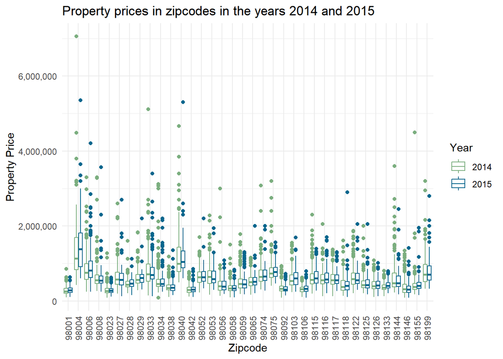

```r
task1 <- df %>%
  mutate(year = substr(date,1,4)) %>%
  group_by(zipcode) %>%
  mutate(how_many = n()) %>%
  filter(how_many > 280) %>%
  group_by(zipcode,year) %>%
  mutate(mean_price = mean(price)) %>%
  select(zipcode,year,mean_price,price) %>%
  distinct()

ggplot(task1, aes(x = as.factor(zipcode), y = price,color = as.factor(year))) +
  geom_boxplot(size = 0.5, position = position_dodge(width = 0.8)) +
  scale_y_continuous(labels = scales::comma) +
  scale_color_manual(values = c("2014" = "#7BAE7F", "2015" = "#05668D"), labels = c("2014", "2015")) +
  labs(x = "Zipcode", y = "Property Price", color = "Year",
       title = "Property prices in zipcodes in the years 2014 and 2015") +
  theme_minimal() +
  theme(axis.text.x = element_text(angle = 90, vjust = 0.5,hjust = 1))
```

**Komentarz: Rozkład cen nieruchomości dla danego kodu pocztowego w latach 2014 i 2015 w większości przypadków jest porównywalny.**

## Zadanie 2

Czy jest różnica w rozkładzie ceny nierchomości od powierzchni mieszkalnej uwzględniając podział na nieruchomości z piwnicą i bez?

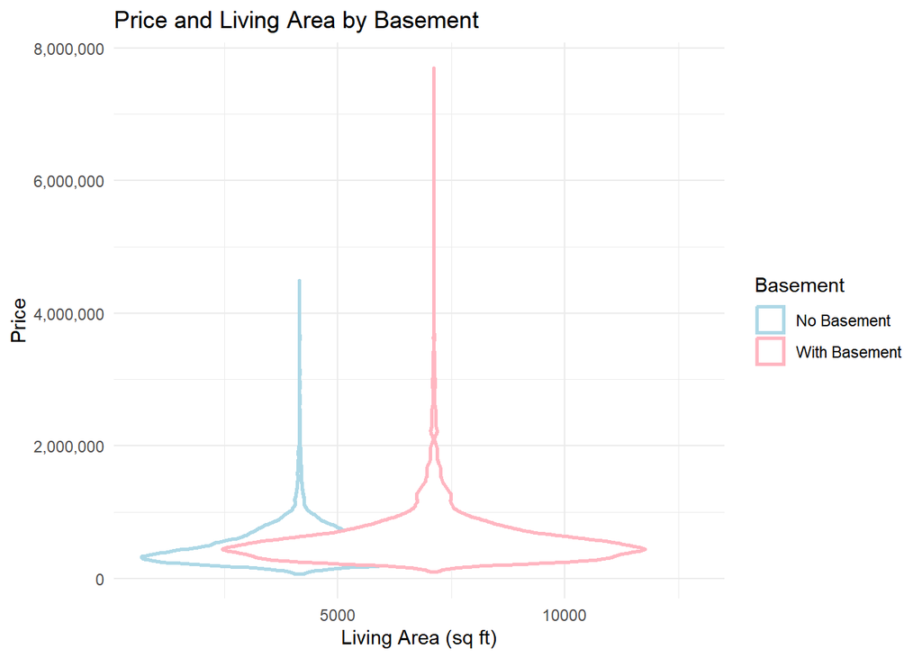

```r
task2 <- df %>%
  mutate(basement = case_when(
    sqft_basement == 0 ~ 0,
    sqft_basement != 0 ~ 1))

ggplot(task2, aes(x = sqft_living, y = price,color = as.factor(basement))) +
  geom_violin(linewidth = 1,position = position_dodge(width = 0.8)) +
  labs(x = "Living Area (sq ft)", y = "Price", color = "Basement",
       title = "Price and Living Area by Basement") +
  scale_color_manual(values = c("0" = "lightblue", "1" = "lightpink"), labels = c("No Basement", "With Basement")) +
  theme_minimal() +
  scale_y_continuous(labels = scales::comma)
```

## Zadanie 3

Jaka jest zależność pomiędzy jakością wykończenia nieruchomości a liczbą pięter?

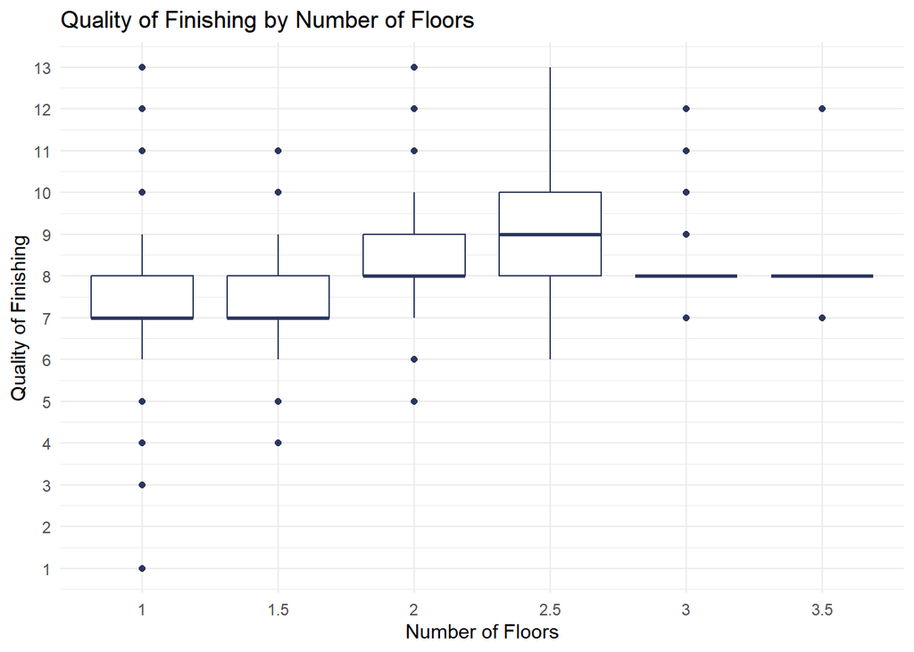

```r
task3 <- df %>%
  filter(!is.na(grade), !is.na(floors))

ggplot(task3, aes(x = as.factor(floors), y = grade)) +
  geom_boxplot(color = "#2C365E") +
  labs(title = "Quality of Finishing by Number of Floors",
       x = "Number of Floors",
       y = "Quality of Finishing") +
  scale_y_continuous(breaks = seq(1, 13, by = 1)) +
  theme_minimal()
```

**Komentarz: Im większa liczba pięter tym najmniejsza jakość wykończenia dla danej kategorii jest wyższa. Również można zauważyć, że bez względu na ilość pięter, większość posiadłości zostało wykończone na poziomie 7/8/9.**

## Zadanie 4

Jaka jest zależność między powierzchnią mieszkalną nieruchomości a powierzchnią gruntu w podziale na liczbę sypialni?

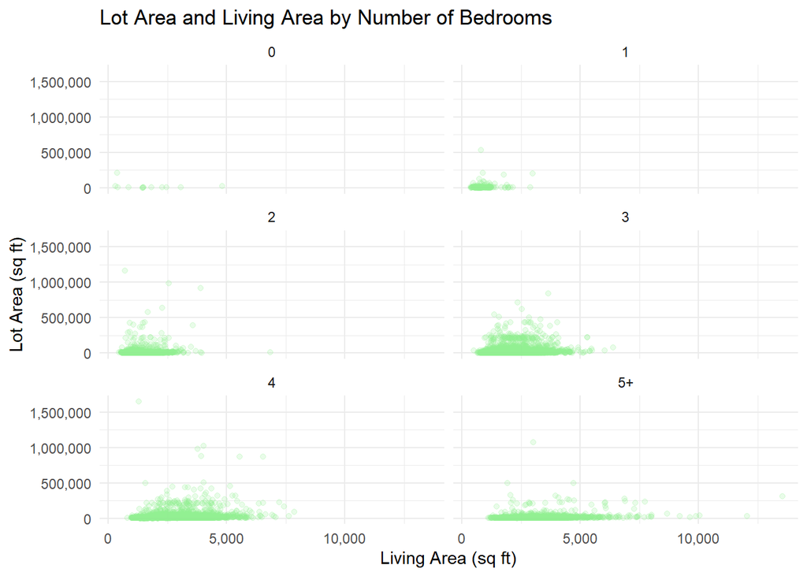

```r
task4 <- df %>%
  mutate(bedrooms_category = case_when(
    bedrooms == 0 ~ "0",
    bedrooms == 1 ~ "1",
    bedrooms == 2 ~ "2",
    bedrooms == 3 ~ "3",
    bedrooms == 4 ~ "4",
    bedrooms >= 5 ~ "5+"
  )) %>%
  filter(!is.na(bedrooms_category))

ggplot(task4, aes(x = sqft_living, y = sqft_lot)) +
  geom_point(alpha = 0.2, size = 1.5,color = "lightgreen") +
  facet_wrap(~ bedrooms_category, ncol = 2) +
  labs(x = "Living Area (sq ft)", y = "Lot Area (sq ft)",
       title = "Lot Area and Living Area by Number of Bedrooms") +
  theme_minimal() +
  scale_y_continuous(labels = scales::comma) +
  scale_x_continuous(labels = scales::comma)
```

**Komentarz: Można zaobserwować, że dla posiadłości z 5 lub wiecej (widać również dla 4) sypialniami powierzchnia działki jest stosunkowo mała do powierzchni mieszkalnej. Oczywistym wnioskiem jest: im więcej jest sypialni, tym większa jest powierzchnia mieszkalna.**

## Zadanie 5

Rozważmy tylko nieruchomości, które miały remont. W której dekadzie było najwięcej przeprowadzonych remontów? Czy w poszczególnych dekadach jest porównywalny procent nieruchmości dla każdej wartości miary jakości i wykończenia nieruchomości?

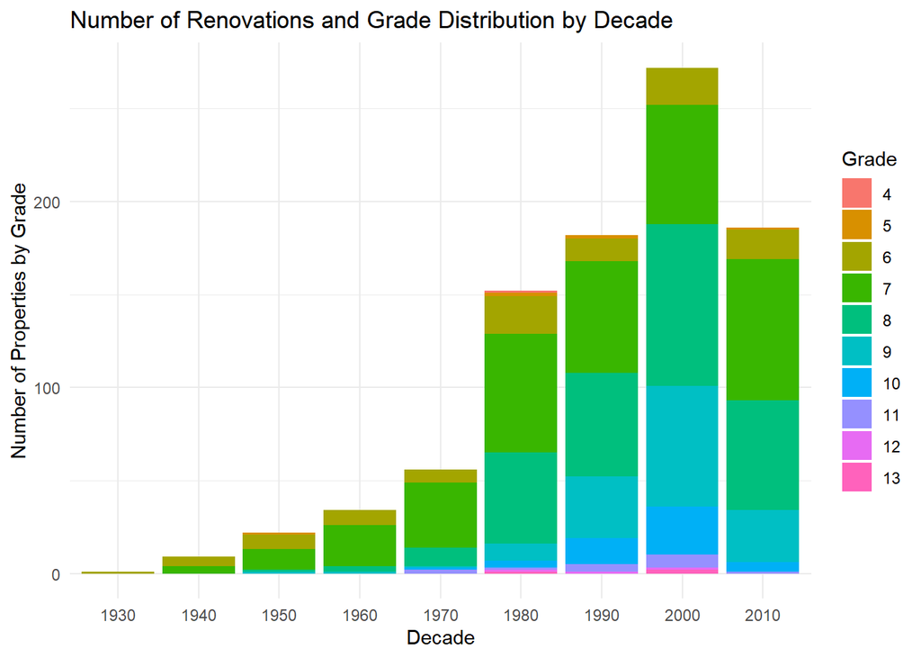

```r
task5 <- df %>%
  filter(yr_renovated != 0) %>%
  mutate(decade = floor(yr_renovated / 10) * 10) %>%
  group_by(decade, grade) %>%
  summarise(count = n(),.groups = "drop_last") %>%
  mutate(procent = count / sum(count) * 100)

ggplot(task5, aes(x = factor(decade), y = count, fill = as.factor(grade))) +
  geom_bar(stat = "identity", position = "stack") +
  labs(title = "Number of Renovations and Grade Distribution by Decade",
       x = "Decade",
       y = "Number of Properties by Grade",
       fill = "Grade") +
  #geom_text(aes(label = paste0(round(procent, 1), "%")),
                   #position = position_stack(vjust = 0.5),
                   #size = 3,
                   #show.legend = FALSE) +
  theme_minimal()
```

## Zadanie 6

Jak prezentuje się wartość minimalna, średnia i maksymalna ceny nieruchmości w podziele na rok budowy nieruchomości.

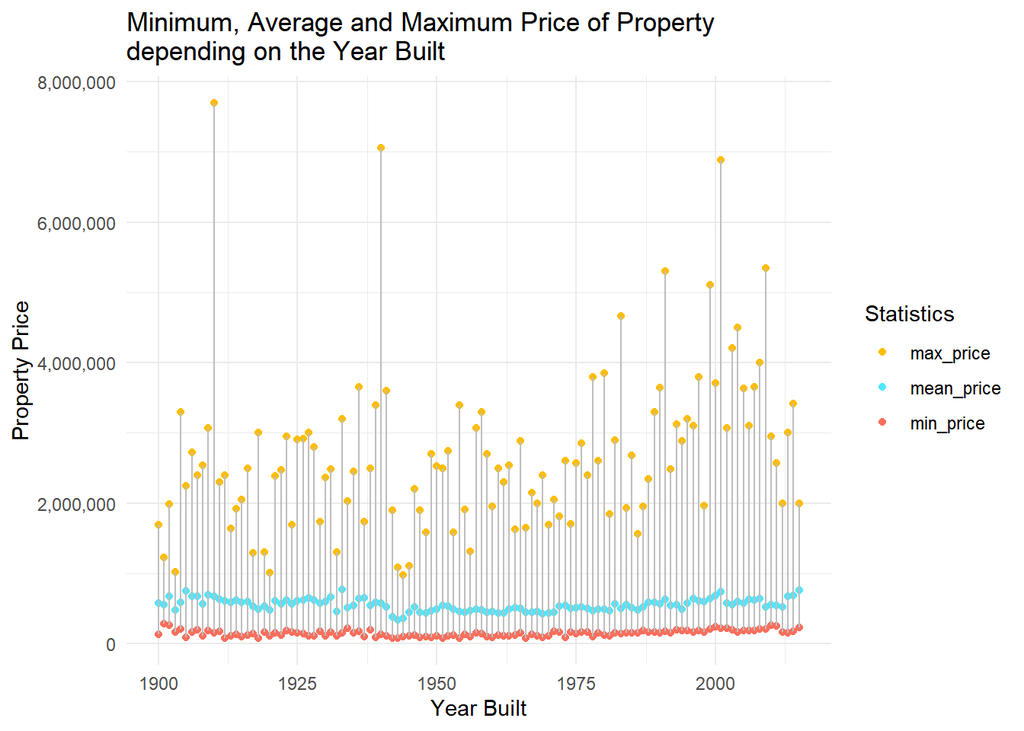

```r
task6 <- df %>%
  group_by(yr_built) %>%
  summarize(
    min_price = min(price),
    mean_price = mean(price),
    max_price = max(price)
  ) %>%
  pivot_longer(cols = c(mean_price, max_price, min_price),
               names_to = "statistic",
               values_to = "value")

ggplot(task6, aes(x = yr_built, y = value, color = statistic)) +
  geom_point(size = 1.5) +
  geom_line(aes(group = yr_built), linewidth = 0.5,color = "gray") +
  scale_color_manual(values = c("min_price" = "#F96F5D", "mean_price" = "#51E5FF", "max_price" = "#FFBD00")) +
  labs(x = "Year Built", y = "Property Price", color = "Statistics",
       title = "Minimum, Average and Maximum Price of Property\ndepending on the Year Built") +
  theme_minimal() +
  scale_y_continuous(labels = scales::comma)
```

**Komentarz: Minimalna oraz średnia wartość nieruchomości na przestrzeni lat jest na podobnym poziomie, natomiast nie można znaleźć wyraźnej zależności maksymalnej ceny nieruchomości od roku.**